# **Cátedra 1: Informe de Análisis de Datos**

Nombre y sigla de la asignatura:** 202410 ACI1018EL_1-9710 PROGRAMACIÓN EN R

Alumno: Jorge Eduardo Melendez Bastías

Fecha Entrega: 22-06-2024 23:59

```r
# Establece el directorio donde están los fuentes a trabajar.
setwd("C:/Users/jorge/OneDrive/MAGISTER/01/PROGRAMACION EN R/EVALUACIONES/EVALUACION 1 (AUTOS)")
```

# 1 Objetivo de investigación

# 2 Objetivo General

Analizar la inscripción de vehículos eléctricos en EE.UU. durante los años 2020-2023, utilizando técnicas de análisis de datos en R Studio y MySQL, con el objetivo de identificar tendencias y patrones que puedan ser útiles en el aprendizaje académico para el postulante a magister en ciencia de datos.

# 3 Objetivos Especificos

- Analizar la evolución del registro de vehículos eléctricos en EE.UU. durante los años 2020-2023.
- Identificar tendencias y patrones en el registro de vehículos eléctricos por tipo de vehículo y estado.
- Utilizar técnicas de programación en R Studio, especialmente las librerías del mundo tidyverse, para el análisis de datos.
- Utilizar MySQL para almacenar y gestionar la gran cantidad de registros, aplicando buenas prácticas para agilizar el análisis.

# 4 Librerías Utilizadas

A continuación las librerías utilizadas en este informe.

```r
library(ini) # Para leer y escribir archivos de configuración en formato INI.
library(janitor) # Para limpiar y examinar datos en R, incluyendo la normalización de nombres de columnas y la identificación de datos duplicados.
library(conflicted) # Resuelve conflictos de nombre de funciones entre paquetes.
library(tidyverse) # Conjunto de paquetes para manipulación de datos, visualización y análisis.
library(ggthemes) # Proporciona temas adicionales y escalas de color para personalizar gráficos de ggplot2.
library(skimr) # Para resumir datos de manera rápida y concisa, proporcionando estadísticas resumidas útiles.
library(knitr) # Para generar tablas en formato markdown, HTML y otros, en R Markdown.
library(kableExtra) # Extiende las capacidades de 'knitr' para formatear tablas y gráficos en HTML.
library(RMySQL) # Para conectarse a bases de datos MySQL desde R.
library(DBI) # Interfaz para bases de datos, abstrae funciones de bajo nivel.
library(sf) # Proporciona funciones para trabajar con datos espaciales.
library(viridis) # Ofrece paletas de colores perceptiblemente uniformes.
source("funciones_jmb_R.R") # Funciones personalizadas creadas por Jorge Melendez para esta cátedra.
```

```r
# Establece preferencias en el uso de funciones filter y lag, dando prioridad a las versiones de dplyr sobre otras posibles definiciones.
conflict_prefer("filter", "dplyr")
conflict_prefer("lag", "dplyr")
```

# 5 Introducción

El conjunto de datos sobre la población de vehículos eléctricos proporciona información detallada sobre los vehículos eléctricos de batería (BEV) y los vehículos híbridos enchufables (PHEV) que están registrados actualmente a través del Departamento de Licencias del Estado de Washington. Los datos incluyen detalles como la marca, el modelo, el año del vehículo y la ubicación de registro. Este conjunto de datos es una valiosa fuente de información para el análisis de la adopción de vehículos eléctricos en la región y está disponible públicamente para su acceso y uso.  
El archivo con objetivo de análisis fue descargado de la siguiente url [https://catalog.data.gov/](https://catalog.data.gov/dataset/electric-vehicle-population-data)

## 5.1 Arquitectura

*La arquitectura se centra en el uso del lenguaje de programación R como herramienta principal para el análisis y modelado de datos. Los datos se importan en R desde diversas fuentes, como archivos CSV en este caso y son almacenadas en base de datos MySQL. Una vez en R, se utilizan varios paquetes para procesar y analizar los datos. Entre estos paquetes se incluyen `tidyverse` para la ciencia de datos, `ggplot2` para la visualización de datos, `dplyr` para la visualización de datos y `rmarkdown` para la creación de documentos dinámicos. Los resultados del análisis se pueden exportar en varios formatos, incluyendo HTML. Además, se utilizan archivos de configuración `.ini` para almacenar variables o ajustes utilizados dentro de este flujo de trabajo.*

[figure not shown]

Arquitectura de alto nivel de la solución para el análisis de datos

## 5.2 Conexión a BD a través de R

```r
# Utiliza la funcion "conectar_mysql_desde_ini" de funciones_jmb_R donde se le entrega como parametro
# el archivo INI con las variables para conectar a MySQL.

archivo_config <- "config.ini"
con <- conectar_mysql_desde_ini(archivo_config)
```

## 5.3 Lectura de los archivos CSV

```r
electric_cars <- read.csv("Electric_Vehicle_Population_Data.csv", sep = ",")
```

## 5.4 Descripción del Conjunto de Datos

Para efectos de investigación técnica de R se almacena la información de la meta data del set de datos a analizar en MySQL en la tabla “metadata_vehiculos”.  
Para propósitos de presentación la tabla se “hermosea” con la función kable.

```r
conjunto_datos <- as_tibble(dbReadTable(con, "metadata_vehiculos"))

kable(conjunto_datos, format = "html") %>%
  kable_styling(bootstrap_options = c("striped", "hover", "condensed", "responsive")) %>%
  add_header_above(c(" " = 1, "Descripción de Variables - Electric Car" = 4)) %>%
  column_spec(1, bold = TRUE) %>%
  row_spec(0, bold = TRUE)
```

| variable | Descripción de Variables - Electric Car descripcion | Descripción de Variables - Electric Car nombre_api | Descripción de Variables - Electric Car tipo_dato | Descripción de Variables - Electric Car tipo_variable |
| --- | --- | --- | --- | --- |
| VIN (Vehicle Identification Number) | Es el Número de Identificación del Vehículo. Se trata de un código alfanumérico único para cada vehículo, y es una de las formas más seguras de identificar un automóvil. | vin_1_10 | Texto | Cualitativo |
| County | Esta es la región geográfica de un estado en la que se registra que reside el propietario de un vehículo. Los vehículos registrados en el estado de Washington pueden estar ubicados en otros estados. | county | Texto | Cualitativo |
| City | La ciudad en la que reside el propietario registrado. | city | Texto | Cualitativo |
| State | Esta es la región geográfica del país asociada con el registro. Estas direcciones pueden estar ubicadas en otros estados. | state | Texto | Cualitativo |
| Postal Code | El código postal de 5 dígitos en el que reside el propietario registrado. | zip_code | Texto | Cualitativo |
| Model Year | El año del modelo del vehículo, determinado mediante la decodificación del Número de Identificación del Vehículo (VIN). | model_year | Texto | Cuantitativo |
| Make | El fabricante del vehículo, determinado mediante la decodificación del Número de Identificación del Vehículo (VIN). | make | Texto | Cualitativo |
| Model | El modelo del vehículo, determinado mediante la decodificación del Número de Identificación del Vehículo (VIN). | model | Texto | Cualitativo |
| Electric Vehicle Type | Esto distingue al vehículo como totalmente eléctrico o híbrido enchufable. | ev_type | Texto | Cualitativo |
| Clean Alternative Fuel Vehicle (CAFV) Eligibility | Esto clasifica al vehículo como Vehículos de Combustible Alternativo Limpio (CAFV) según el requisito de combustible y el requisito de alcance solo eléctrico en la Ley 2042 aprobada en la sesión legis… | cafv_type | Texto | Cualitativo |
| Electric Range | Describe la distancia que un vehículo puede recorrer únicamente con su carga eléctrica. | electric_range | Número | Cuantitativo |
| Base MSRP | Este es el Precio de Venta Sugerido por el Fabricante (MSRP) más bajo para cualquier nivel de equipamiento del modelo en cuestión. | base_msrp | Número | Cuantitativo |
| Legislative District | La sección específica del estado de Washington en la que reside el propietario del vehículo, según lo representado en la legislatura estatal. | legislative_district | Texto | Cualitativo |
| DOL Vehicle ID | Número único asignado a cada vehículo por el Departamento de Licencias para fines de identificación. | dol_vehicle_id | Texto | Cualitativo |
| Vehicle Location | El centro del código postal del vehículo registrado. | geocoded_column | Punto | Cualitativo |
| Electric Utility | Estas son las áreas de servicio de energía eléctrica al por menor que atienden la dirección del vehículo registrado. Se incluyen todos los tipos de propiedad para áreas en Washington: federal, propied… | electric_utility | Texto | Cualitativo |
| 2020 Census Tract | El identificador del tracto censal es una combinación de los códigos de estado, condado y tracto censal asignados por la Oficina del Censo de los Estados Unidos en el censo de 2020, también conocido c… | _2020_census_tract | Texto | Cualitativo |

# 6 Preprocesamiento de Datos

## 6.1 Algunas consideraciones al trabajar con MySQL y R

Se deben realizar algunas configuraciones para el almacén de datos desde R a MySQl

```r
# Habilitar local_infile globalmente
# se debe configurar para recibir datos de manera externa.
# tambien ver esta configuracion:
# https://medium.com/@kiena/troubleshooting-dbeaver-public-key-retrieval-is-not-allowed-error-29f203d745c5
# dbExecute(con, "SET @@GLOBAL.local_infile = 1;")
```

## 6.2 Analisis y Limpieza del data set.

El siguiente código en R realiza una serie de pasos para preparar y limpiar un conjunto de datos sobre vehículos eléctricos. Primero, lee los datos de una base de datos y los convierte a un formato de tabla. Luego, limpia los nombres de las columnas para que sean más manejables. A continuación, transforma ciertas columnas numéricas a caracteres y otras a factores, lo que facilita su análisis. El código identifica y guarda los registros con datos faltantes y, finalmente, elimina esas filas con valores perdidos del conjunto de datos, dejando solo los registros completos para el análisis posterior.

```r
# Lectura de datos
electric_cars <- as_tibble(dbReadTable(con, "electric_cars"))

# Limpieza de nombres de columnas
electric_cars <- electric_cars %>% clean_names()

# Limpieza de columnas - Transformación de columnas numeric -> char
electric_cars <- electric_cars %>%
  mutate_at(vars(postal_code, legislative_district,
                 legislative_district, dol_vehicle_id, x2020_census_tract), as.character)

# Transformación de columnas de numéricas a factores
electric_cars <- electric_cars %>%
  mutate_at(vars(model_year, electric_vehicle_type,
                 clean_alternative_fuel_vehicle_cafv_eligibility), as.factor)

# identificacion de datos perdidos
datos_perdidos <- electric_cars %>% filter(rowSums(is.na(.)) > 0) #414 registros


# Eliminar filas con valores perdidos
electric_cars <- na.omit(electric_cars)
```

## 6.3 Revisión de data set

Se revisa el data set para ver el resultado después de la aplicación de limpieza.

```r
skim(electric_cars)
```

Table 6.1: Data summary

| Name | electric_cars |
| --- | --- |
| Number of rows | 190993 |
| Number of columns | 17 |
| _______________________ |  |
| Column type frequency: |  |
| character | 12 |
| factor | 3 |
| numeric | 2 |
| ________________________ |  |
| Group variables | None |

**Variable type: character**

| skim_variable | n_missing | complete_rate | min | max | empty | n_unique | whitespace |
| --- | --- | --- | --- | --- | --- | --- | --- |
| vin_1_10 | 0 | 1 | 10 | 10 | 0 | 11480 | 0 |
| county | 0 | 1 | 4 | 12 | 0 | 39 | 0 |
| city | 0 | 1 | 3 | 24 | 0 | 477 | 0 |
| state | 0 | 1 | 2 | 2 | 0 | 1 | 0 |
| postal_code | 0 | 1 | 5 | 5 | 0 | 553 | 0 |
| make | 0 | 1 | 3 | 20 | 0 | 42 | 0 |
| model | 0 | 1 | 2 | 24 | 0 | 147 | 0 |
| legislative_district | 0 | 1 | 1 | 2 | 0 | 49 | 0 |
| dol_vehicle_id | 0 | 1 | 4 | 9 | 0 | 190993 | 0 |
| vehicle_location | 0 | 1 | 0 | 31 | 4 | 553 | 0 |
| electric_utility | 0 | 1 | 10 | 112 | 0 | 74 | 0 |
| x2020_census_tract | 0 | 1 | 11 | 11 | 0 | 1768 | 0 |

**Variable type: factor**

| skim_variable | n_missing | complete_rate | ordered | n_unique | top_counts |
| --- | --- | --- | --- | --- | --- |
| model_year | 0 | 1 | FALSE | 23 | 202: 60005, 202: 28046, 202: 19462, 202: 16944 |
| electric_vehicle_type | 0 | 1 | FALSE | 2 | Bat: 149397, Plu: 41596 |
| clean_alternative_fuel_vehicle_cafv_eligibility | 0 | 1 | FALSE | 3 | Eli: 101954, Cle: 68610, Not: 20429 |

**Variable type: numeric**

| skim_variable | n_missing | complete_rate | mean | sd | p0 | p25 | p50 | p75 | p100 | hist |
| --- | --- | --- | --- | --- | --- | --- | --- | --- | --- | --- |
| electric_range | 0 | 1 | 55.63 | 90.13 | 0 | 0 | 0 | 72 | 337 | ▇▁▁▂▁ |
| base_msrp | 0 | 1 | 994.05 | 8047.59 | 0 | 0 | 0 | 0 | 845000 | ▇▁▁▁▁ |

## 6.4 Almacenamiento en MySQL

Este código en R informa sobre el proceso de escribir datos en una base de datos. Primero, muestra un mensaje indicando que la escritura está en curso y la hora actual. Luego, guarda los datos de electric_cars en la tabla “electric_cars” de la base de datos, reemplazando cualquier contenido previo. Finalmente, muestra un mensaje confirmando que los datos se escribieron exitosamente, junto con la hora en que se completó la operación.

```r
message(paste("Escribiendo datos en la base de datos... por favor espera. - ", Sys.time()))
dbWriteTable(con, "electric_cars", electric_cars, overwrite = TRUE, append = FALSE, row.names = FALSE)
```

```
## [1] TRUE
```

```r
message(paste("Datos escritos exitosamente en la base de datos. - ", Sys.time()))
```

# 7 Análisis Exploratorio de Datos

El objetivo del Análisis Exploratorio de Datos (EDA) es resumir las características principales de los datos, a menudo con métodos visuales. En este informe, se explorarán las variables seleccionadas y se identificarán patrones, anomalías y relaciones entre las variables.

## 7.1 Revisión de vehiculos eléctricos por año.

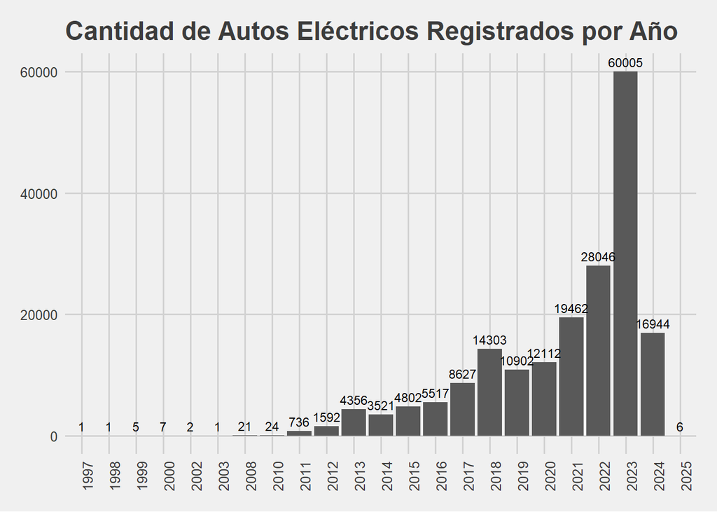

```r
# Crear un gráfico de barras para mostrar la cantidad de autos por año
ggplot(data = electric_cars, aes(x = model_year)) +
  geom_bar() +
  geom_text(stat = "count", aes(label = ..count..), vjust = -0.5, size = 3, color = "black") +
  labs(title = "Cantidad de Autos Eléctricos Registrados por Año",
       x = "Año del Modelo",
       y = "Cantidad de Autos") +
  theme_fivethirtyeight() +
  theme(axis.text.x = element_text(angle = 90, hjust = 1))
```

El gráfico muestra la cantidad de autos eléctricos registrados por año. En el eje horizontal, tenemos los años del modelo (desde 1997 hasta 2025), y en el eje vertical, la cantidad de autos eléctricos. A partir del año 2021, se observa un notable aumento en los registros, indicando una creciente adopción de vehículos eléctricos. En 2023, se registraron aproximadamente 60.000 autos eléctricos.

## 7.2 Revisión de las top 20 marcas en el mercado de vehículos eléctricos.

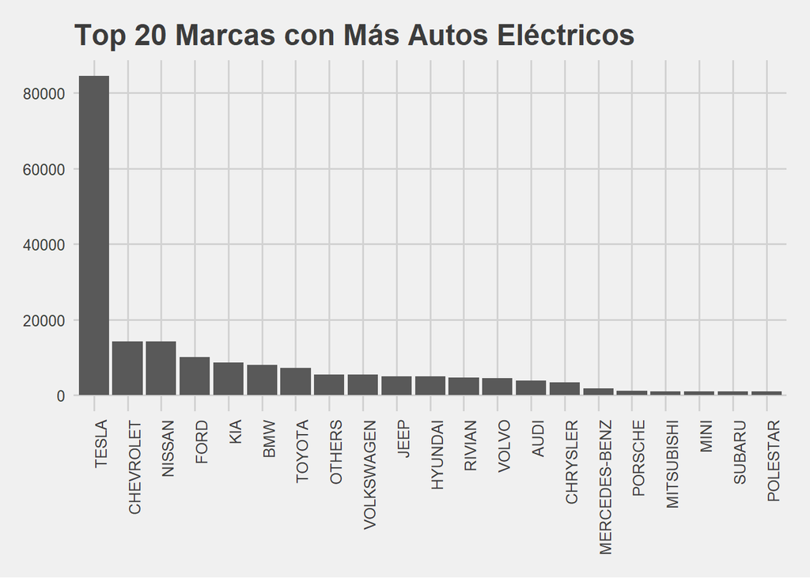

```r
# Obtener las 20 marcas con más autos
top_brands <- electric_cars %>%
  count(make, sort = TRUE) %>%
  top_n(20, n)

# Crear una columna que agrupa las marcas en 'Otras' si no están en las top 20
electric_cars <- electric_cars %>%
  mutate(make_grouped = ifelse(make %in% top_brands$make, make, "OTHERS"))

top_brands <- electric_cars %>%
  count(make_grouped, sort = TRUE)

# Gráfico de barras para mostrar la cantidad de autos por marca (top 20)
ggplot(data = top_brands, aes(x = reorder(make_grouped, -n), y = n)) +
  geom_bar(stat = "identity") +
  labs(title = "Top 20 Marcas con Más Autos Eléctricos",
       x = "Marca",
       y = "Cantidad de Autos") +
  theme_fivethirtyeight() +
  theme(axis.text.x = element_text(angle = 90, hjust = 1))
```

Claramente la predominancia de TESLA en el mercado de autos eléctricos con una cantidad significativamente mayor en comparación con otras marcas reconocidas en el mercado Estadounidense.

## 7.3 Análisis de la distribución de autos eléctricos por ciudad

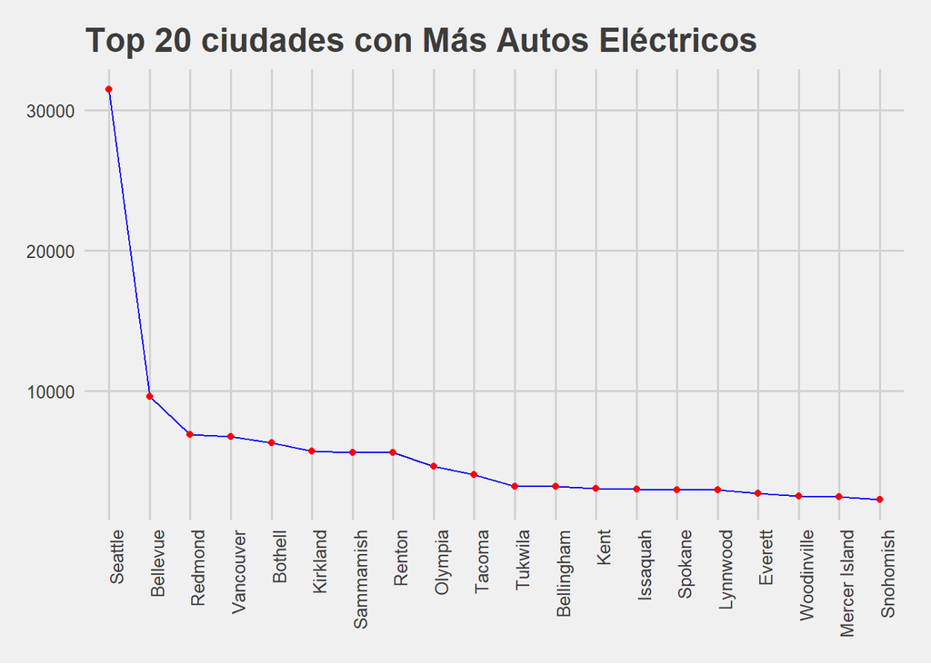

```r
# Obtener las 20 marcas con más autos
top_cities <- electric_cars %>%
  count(city, sort = TRUE) %>%
  top_n(20, n)

# Gráfico de lineas para mostrar las ciudades con mas autos electricos

ggplot(data = top_cities, aes(x = reorder(city, -n), y = n, group = 1)) +
  geom_line(color = "blue") +
  geom_point(color = "red") +
  labs(title = "Top 20 ciudades con Más Autos Eléctricos",
       x = "Ciudad",
       y = "Cantidad de Autos") +
  theme_fivethirtyeight() +
  theme(axis.text.x = element_text(angle = 90, hjust = 1))
```

Seattle es la ciudad con mas automóviles eléctricos contenidos en el set de datos. Un articulo interesante a revisar es [NPR Network](https://www.kuow.org/stories/electric-vehicles-keep-charging-ahead-in-washington)

## 7.4 Dispersión de cada vehículo en el mapa del estado WA de EEUU.

```r
# Llama a la función "extract_coordinates" de funciones_jmb_R
electric_cars_sf <- extract_coordinates(electric_cars, "vehicle_location")

# Lee archivo geospacial SHP
wa <- st_read("shp_2/WSDOT_-_County_Road_(CRAB).shp")
```

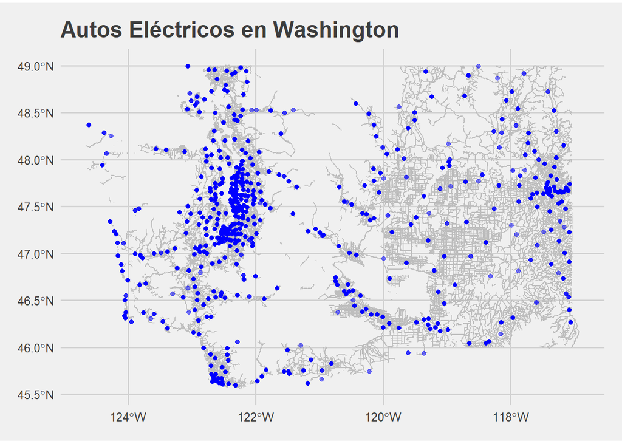

```r
# Grafico de puntos con la capa geoespacial.
ggplot() +
  geom_sf(data = wa, color = "grey", fill = "lightblue") +
  geom_sf(data = electric_cars_sf, color = "blue", alpha = 0.5) +
  labs(title = "Autos Eléctricos en Washington") +
  theme_fivethirtyeight()
```

El mapa muestra la distribución de autos eléctricos en el estado de Washington. La mayor densidad de puntos se encuentra en la ciudad de Seattle.

## 7.5 Segmentación de Vehículos dada su fuente de alimentación.

```r
# Calcular el porcentaje de cada tipo de vehículo eléctrico
electric_cars_segmento <- electric_cars %>%
  count(electric_vehicle_type) %>%
  mutate(percent = n / sum(n) * 100)

electric_cars_segmento
```

| electric_vehicle_type | n | percent |
| --- | --- | --- |
| Battery Electric Vehicle (BEV) | 149397 | 78.22119 |
| Plug-in Hybrid Electric Vehicle (PHEV) | 41596 | 21.77881 |

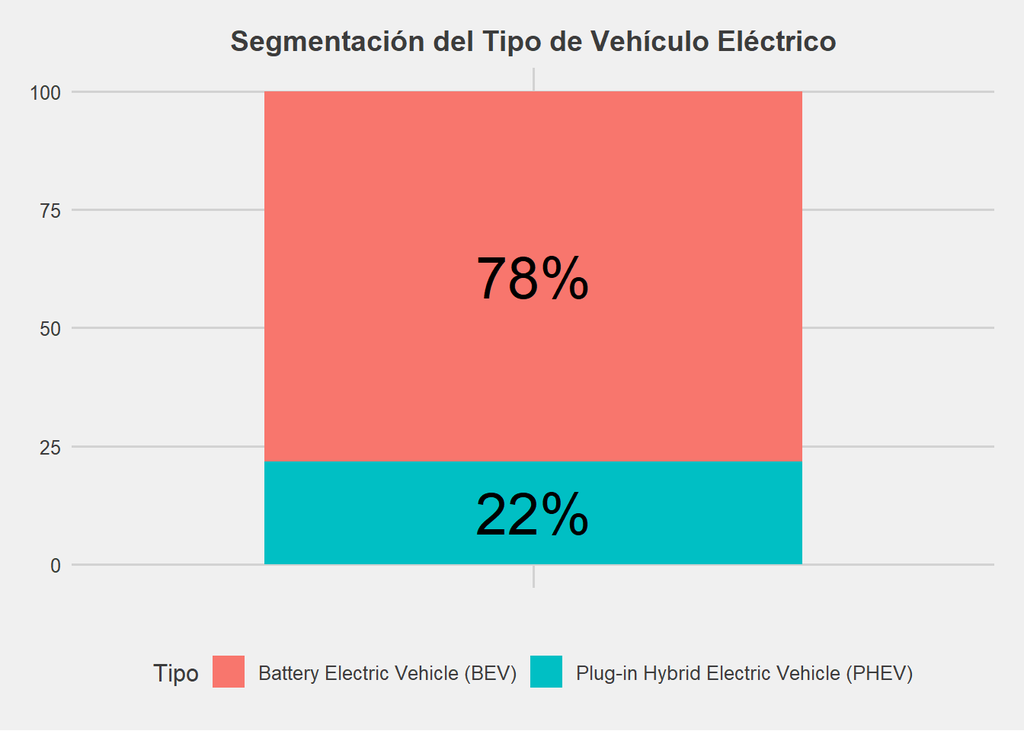

```r
# Gráfico de pastel para mostrar la segmentación del tipo de vehículo eléctrico
ggplot(data = electric_cars_segmento, aes(x = "", y = percent, fill = electric_vehicle_type)) +
  geom_bar(stat = "identity", width = 0.7) +
  geom_text(aes(label = paste0(round(percent), "%")), position = position_stack(vjust = 0.5), size = 10) +
  labs(title = "Segmentación del Tipo de Vehículo Eléctrico",
       fill = "Tipo") +
  theme_fivethirtyeight() +
  theme(plot.title = element_text(hjust = 0.5, size = 14))
```

Existe una gran predominancia de los vehículos con batería (149.397) por sobre los vehiculos hibridos (41.596).

## 7.6 Análisis de la elegibilidad de vehículos CAFV

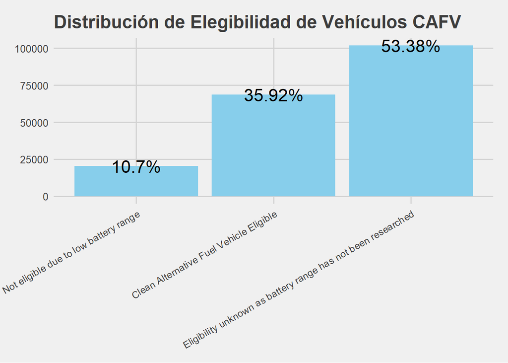

```r
# Calcular los porcentajes
cafv_counts <- table(electric_cars$clean_alternative_fuel_vehicle_cafv_eligibility)
cafv_perc <- round(prop.table(cafv_counts) * 100, 2)

# Crear un data frame con los datos
df <- data.frame(
  Elegibilidad = names(cafv_counts),
  Cantidad = as.numeric(cafv_counts),
  Porcentaje = cafv_perc
)

# Gráfico de barras horizontales con porcentajes
ggplot(data = df, aes(x = reorder(Elegibilidad, Cantidad), y = Cantidad, label = paste0(Porcentaje.Freq, "%"))) +
  geom_bar(stat = "identity", fill = "skyblue") +
  geom_text(size = 6) +
  labs(title = "Distribución de Elegibilidad de Vehículos CAFV",
       x = "Elegibilidad",
       y = "Cantidad de Autos") +
  theme_fivethirtyeight() +
  theme(axis.text.y = element_text(size = 10))+
  theme(axis.text.x = element_text(angle = 30, hjust = 1))
```

Los vehículos CAFV suelen ser aquellos que utilizan combustibles alternativos, como electricidad, hidrógeno, gas natural comprimido (GNC) o gas licuado de petróleo (GLP), en lugar de gasolina o diésel tradicionales. Estos vehículos son una parte importante de los esfuerzos para reducir las emisiones de gases de efecto invernadero y mejorar la calidad del aire.

Respecto a la distribución de elegibilidad de vehículos CAFV muestra que la mayoría de los vehículos tienen una elegibilidad desconocida (53.38%) debido a que no se ha investigado su autonomía de batería, seguido por aquellos que son elegibles como vehículos CAFV (35.92%). Un número significativamente menor de vehículos no son elegibles debido a su baja autonomía de batería (10.70%). Esto destaca la importancia de investigar y documentar la autonomía de la batería de los vehículos para una clasificación precisa de su elegibilidad como vehículos CAFV.

# 8 Modelado de Datos